# Classification

## Naive Bayesian

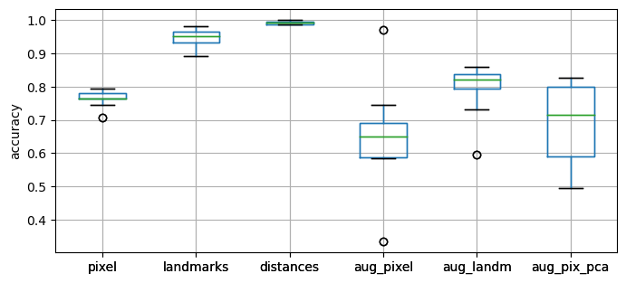

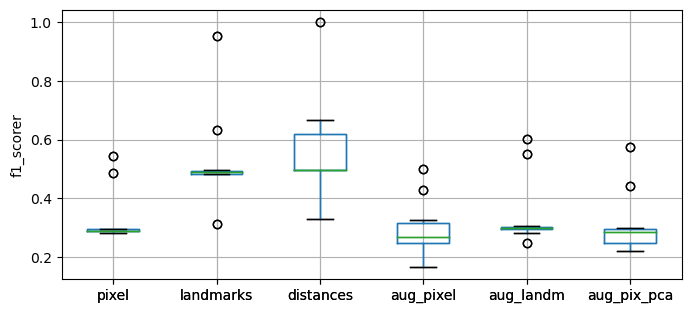

```
Mean accuracy scores:
'pixel':  0.7637132922793347
'landmarks':  0.9449874686716792
'distances':  0.9913943950786056
'aug_pixel':  0.6490087410306589
'aug_landm':  0.7933198995846045
'aug_pix_pca':  0.6932433137638617

Mean f1 scores:
'pixel':  0.3352437449529858
'landmarks':  0.5317179828105127
'distances':  0.5643911915710057
'aug_pixel':  0.2996738498626803
'aug_landm':  0.34876738647726835
'aug_pix_pca':  0.316184544577926

Mean score time:
'pixel':  0.041062664985656736
'landmarks':  0.01169881820678711
'distances':  0.010998702049255371
'aug_pixel':  0.09860453605651856
'aug_landm':  0.014199614524841309
'aug_pix_pca':  0.06800870895385742
```

```python
from sklearn.naive_bayes import GaussianNB
gc = GaussianNB()

results_list = test_classifier(gc, X_list, y_list);
plot_results(results_list)
```

```
pixel
```

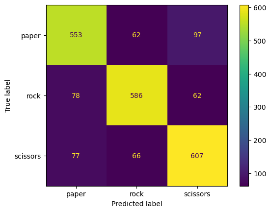

```
landmarks
```

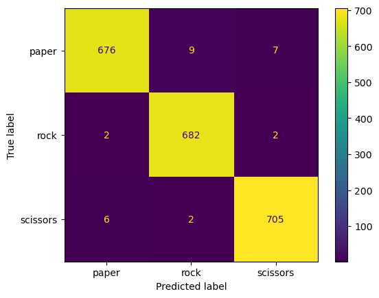

```
distances
```

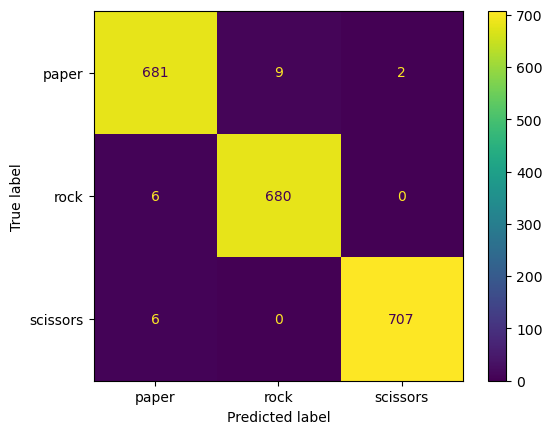

```
aug_pixel
```

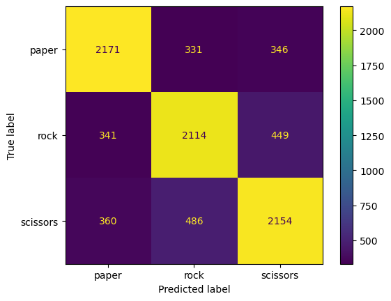

```
aug_landm
```

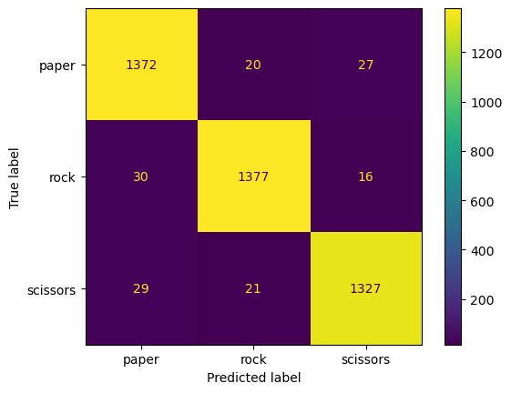

```
aug_pix_pca
```

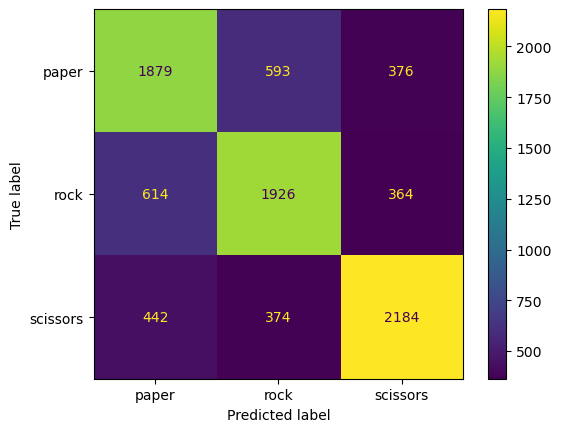

```python
plot_confusion_matrix(gc, X_list, y_list)
```

## Random Forest Classifier

### n_estimators = 50

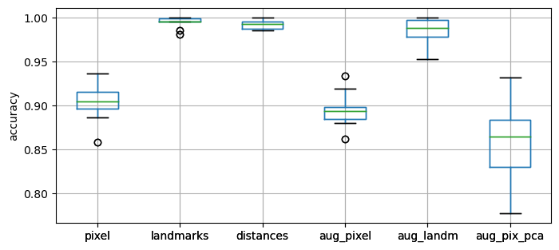

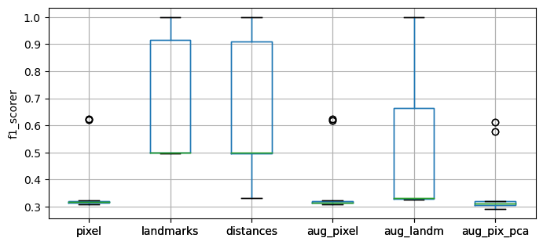

```
Mean accuracy scores:
'pixel':  0.9026643207238909
'landmarks':  0.9942583732057416
'distances':  0.9923513328776487
'aug_pixel':  0.8947671232876713
'aug_landm':  0.985538832164447
'aug_pix_pca':  0.8574054794520548

Mean f1 scores:
'pixel':  0.3774772922790044
'landmarks':  0.664973372921876
'distances':  0.6474579337717182
'aug_pixel':  0.37554752497295074
'aug_landm':  0.5302684618634061
'aug_pix_pca':  0.36499454552291444

Mean score time:
'pixel':  0.042006397247314455
'landmarks':  0.025304412841796874
'distances':  0.02390279769897461
'aug_pixel':  0.07920694351196289
'aug_landm':  0.028102731704711913
'aug_pix_pca':  0.0850083589553833
```

```python
from sklearn.ensemble import RandomForestClassifier
rf = RandomForestClassifier(n_estimators = 50)
results_list = test_classifier(rf, X_list, y_list);
plot_results(results_list)
```

```
pixel
```

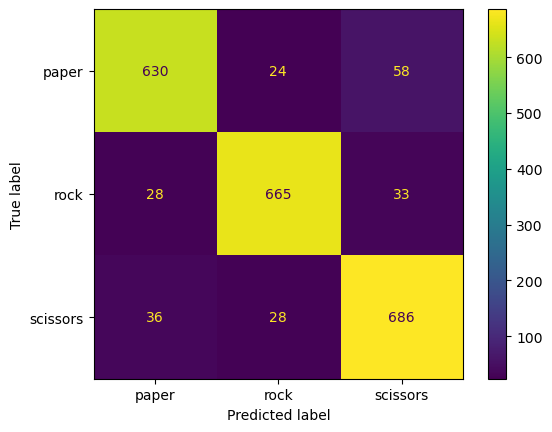

```
landmarks
```

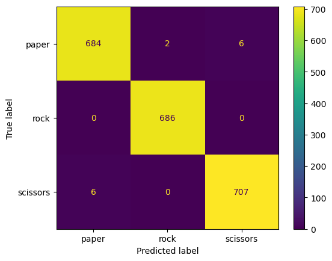

```
distances
```

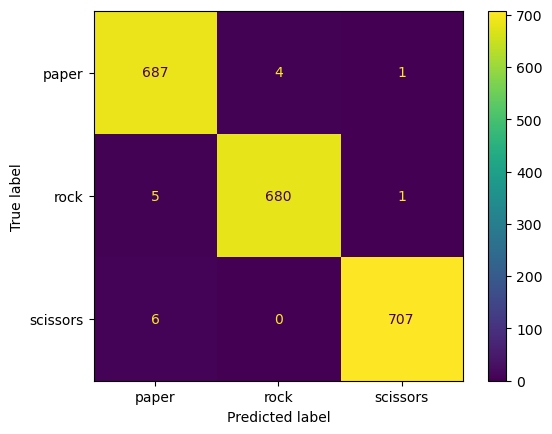

```
aug_pixel
```

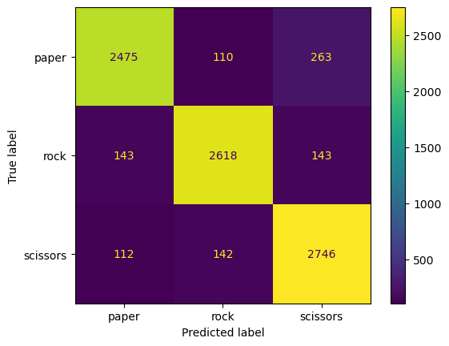

```
aug_landm
```

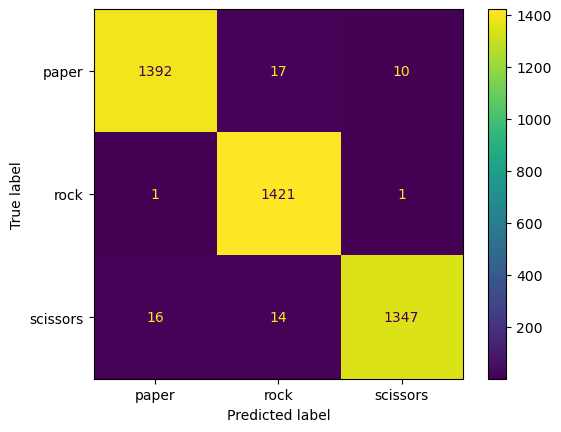

```
aug_pix_pca
```

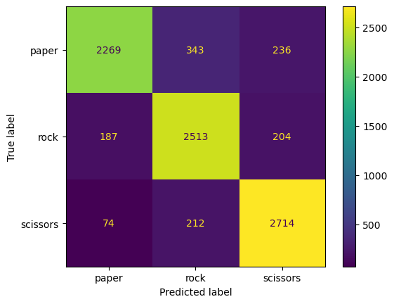

```python
plot_confusion_matrix(rf, X_list, y_list)
```

## Random Forest Classifier

### n_estimators = 100

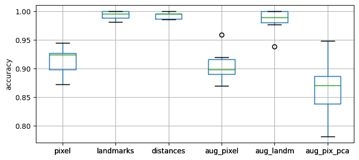

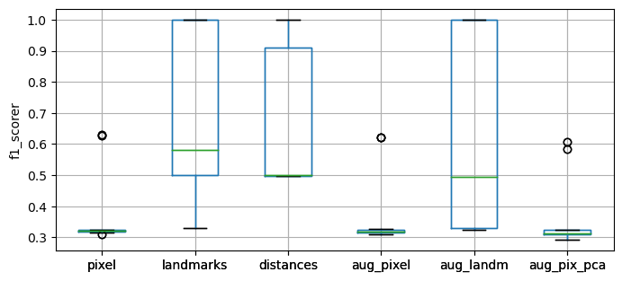

```
Mean accuracy scores:
'pixel':  0.9140966025721586
'landmarks':  0.9937799043062201
'distances':  0.9928298017771702
'aug_pixel':  0.9036803652968036
'aug_landm':  0.9857769247222253
'aug_pix_pca':  0.865173385518591

Mean f1 scores:
'pixel':  0.38054248930382906
'landmarks':  0.6985904508381651
'distances':  0.6641649527719027
'aug_pixel':  0.37745762783513287
'aug_landm':  0.6302343791652687
'aug_pix_pca':  0.3666290480666409

Mean score time:
'pixel':  0.055503344535827635
'landmarks':  0.04020414352416992
'distances':  0.03890359401702881
'aug_pixel':  0.12120974063873291
'aug_landm':  0.04080433845520019
'aug_pix_pca':  0.11961042881011963
```

```python
from sklearn.ensemble import RandomForestClassifier
rf = RandomForestClassifier(n_estimators = 100)
results_list = test_classifier(rf, X_list, y_list);
plot_results(results_list)
```

```
pixel
```

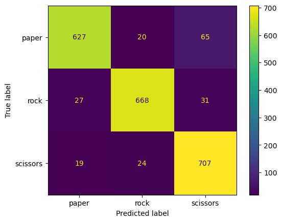

```
landmarks
```

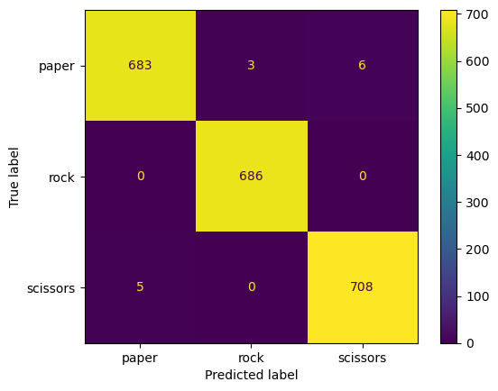

```
distances
```

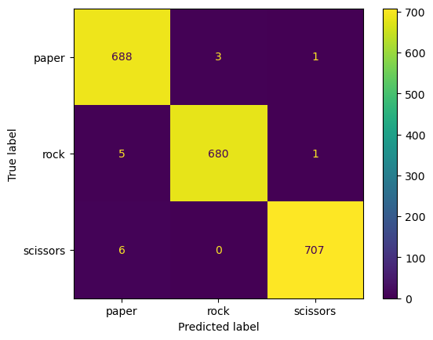

```
aug_pixel
```

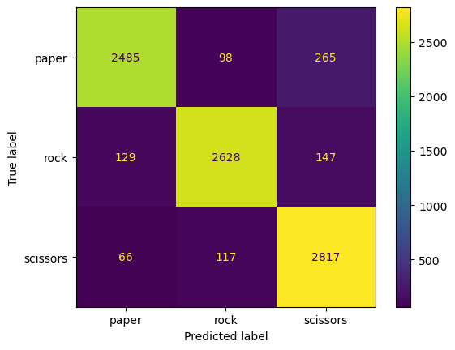

```
aug_landm
```

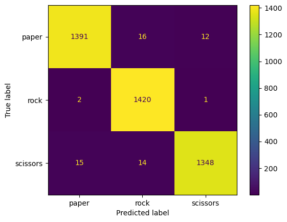

```
aug_pix_pca
```

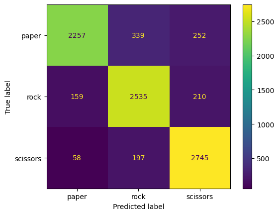

```python
plot_confusion_matrix(rf, X_list, y_list)
```

## Classification Report

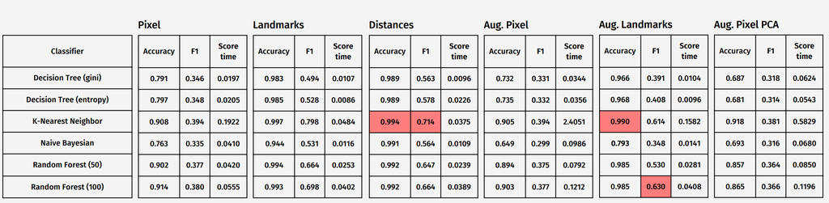

# Exporting Models for the Implementation

The best classifier for the distances Dataset is the K-Nearest Neighbor with k = 1, best both in terms of accuracy and f1 score. Also for the augmented dataset that has landmarks as features the best in term of accuracy is the K-Nearest Neighbor, in this case, however, the best for the f1 score is RandomForest (n_estimator = 100). I choose RandomForest because it is faster in classification. I have not implemented models that work with pixels because they are not general enough, probably a greenscreen is needed to be used.

```python
from sklearn.neighbors import KNeighborsClassifier
from sklearn.ensemble import RandomForestClassifier

knn_distances = KNeighborsClassifier(n_neighbors = 1)
rf_aug_landmarks = RandomForestClassifier(n_estimators = 100)

knn_distances.fit(X_list[2], y_list[2])
rf_aug_landmarks.fit(X_list[4], y_list[4])

print(knn_distances.n_features_in_)
print(rf_aug_landmarks.n_features_in_)
```

```
5
42
```

```python
import joblib
joblib.dump(knn_distances, "C:/Users/matte/PycharmProjects/pythonProject1/models/knn_distances.pkl");
joblib.dump(rf_aug_landmarks, "C:/Users/matte/PycharmProjects/pythonProject1/models/rf_aug_landmarks.pkl");
```